### Interface for JSON Data

#### Overview

The New York Times web site provides a rich set of APIs, as described here: https://developer.nytimes.com/apis

The task is to choose one of the New York Times APIs, construct an interface in R to read in the JSON data, and transform it into an R DataFrame.

[figure not shown]

#### Packages

```r
library(knitr)
library(jsonlite)
library(httr)
library(glue)
library(dplyr)
library(shiny)
```

#### Parameters

**Construct an interface in R to read in the JSON data, and transform it into an R Data Frame.**

1. Construct URL Parameter with the desired data to be obtained

```r
# https://api.nytimes.com/svc/books/v3/lists/current/hardcover-fiction.json?api-key=yourkey
```

2.- Obtain Json File from API

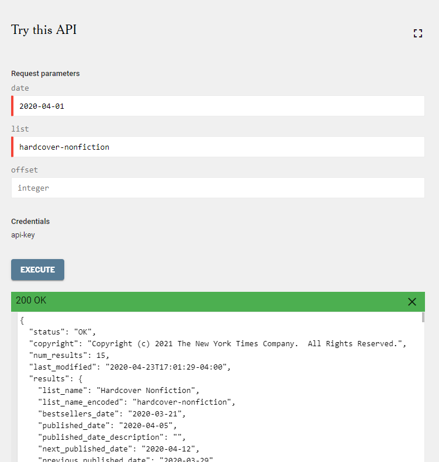

Json

#### Read API

For this project I chose to use the Books API. In order to obtain the information we need to specify certain parameters to obtain specific data (as opposed to all the data available)

```r
url_string <- "https://api.nytimes.com/svc/books/v3/lists/{date}/{list}.json?api-key={api_key}"
```

**Parameters**

The search parameters for are as follows:

- List -> Hardcover-nonfiction Books
- Date -> Which are the best sellers during Covid - April 2020

```r
api_key <- Sys.getenv("NYT_TOKEN")
list <- "hardcover-nonfiction"
date <- "2020-04-01"
```

Once parameters are set - we use JSONlite and HTTR to create a function and “GET” the information we requested in the parameters which is inside the the content variable.

```r
raw.data <- fromJSON(rawToChar(GET(glue(url_string))$content))
book.data <- raw.data$results$books
```

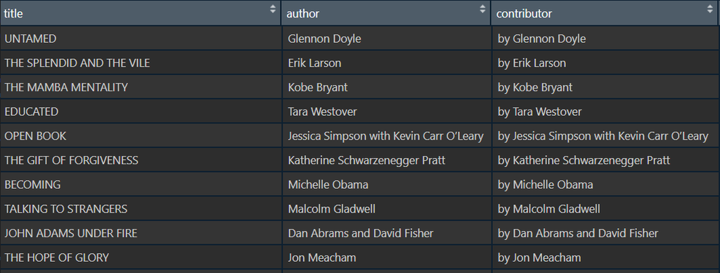

#### Dataframe

For the purpose of this project we will work with the following variables.

- Title
- Author
- Weeks on list
- Description
- Book Image

```r
book.rank.df <-
  book.data[,c("rank",
               "weeks_on_list",
               "title",
               "author",
               "description",
               "book_image")]
```

**Final Result**

```r
kable(head(book.rank.df,5),caption = "NYT Hardcover Nonfiction Top 5")
```

NYT Hardcover Nonfiction Top 5

| rank | weeks_on_list | title | author | description | book_image |
| --- | --- | --- | --- | --- | --- |
| 1 | 2 | UNTAMED | Glennon Doyle | The activist and public speaker describes her journey of listening to her inner voice. | https://storage.googleapis.com/du-prd/books/images/9781984801258.jpg |
| 2 | 4 | THE SPLENDID AND THE VILE | Erik Larson | An examination of the leadership of the prime minister Winston Churchill. | https://storage.googleapis.com/du-prd/books/images/9780385348713.jpg |
| 3 | 14 | THE MAMBA MENTALITY | Kobe Bryant | Various skills and techniques used on the court by the late Los Angeles Lakers player. | https://storage.googleapis.com/du-prd/books/images/9780374201234.jpg |
| 4 | 109 | EDUCATED | Tara Westover | The daughter of survivalists, who is kept out of school, educates herself enough to leave home for university. | https://storage.googleapis.com/du-prd/books/images/9780399590504.jpg |
| 5 | 7 | OPEN BOOK | Jessica Simpson with Kevin Carr O’Leary | The singer, actress and fashion designer discloses times of success, trauma and addiction. | https://storage.googleapis.com/du-prd/books/images/9780062899965.jpg |